# Geostatistics

## 2. Univariate statistics

### 2.1 Why statistics?

Usually we do not know all possible system states. And even if, it would be hard to describe *system behavior* while taking all states into consideration. Thus, we usually try to describe a *common* state, or a representative one.

This already implies that the question of how to describe a system using means of statistics is already bound to the context. It is important **why** we want to describe that system.

Let's load one of the data sets of the last lecture:

```python
print(data[:5], '...', data[:5])
```

```
[-0.16441089  0.03598559 -0.18827199  0.36503706 -0.02894305] ... [-0.16441089  0.03598559 -0.18827199  0.36503706 -0.02894305]
```

#### Expected Value

First, we can describe the **distribution** of observations by their **mean** value. In statistics, this is often referred to as the **expected value**.

```python
sum(data) / len(data)
```

```
0.7583277269546096
```

But does `0.76` (approx.) really describe the other values?

How many of them are off by only `0.1`?

```python
mu = sum(data) / len(data)
close = sum([abs(x - mu) < 0.1 for x in data])
print('%d of %d values are closer than 0.1' % (close, len(data)))
```

```
43 of 500 values are closer than 0.1
```

#### Variance

What we did in the last slide was trying to estimate a measure for the dispersion of the distribution. The more systematic way to do so is calculating the **variance**.

$$ s^2 = \frac{\sum_{i=0}^N (x_i - \mu)^2}{N} $$

```python
v = sum((data - mu)**2) / len(data)
print('The variance is %.2f' % v)
```

```
The variance is 0.78
```

#### Standard deviation

The value $s$ used to calculate the *variance* $s^2$ is also called **standard deviation**. When we set the threshold to `0.1` earlier to get an idea of how many observations are close to the mean value, we also could have used the standard deviation. It is an important measure for the spread of a distribution.

```python
sqrt(v)
```

```
0.8815188576246978
```

#### Covariance

- two samples origin from the same probability distribution
- relates the samples *monotonically*

$$Cov(X, Y) = \frac{\sum_i^N [(x_i - \mu_X) * (y_i - \mu_Y)]}{N}$$

```python
# get the samples - you can change the numbers
X = df.iloc[:, 14].values
Y = df.iloc[:, 10].values

# sample means
mX = sum(X) / len(X)
mY = sum(Y) / len(Y)

cov = sum([(x - mX) * (y - mY) for x,y in zip(X, Y)]) / len(X)

print('Cov(X,Y) = ', cov)
```

```
Cov(X,Y) =  0.19403510392660436
```

### 2.2 Sample size

All the statistical moments shown above are *sample statistics*. They are no features of the underlying population. That means, they are all influenced by sample size.

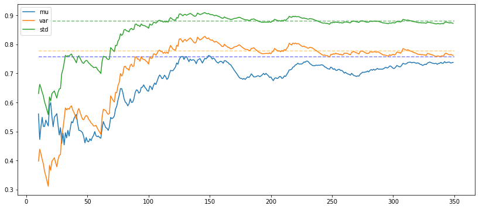

```python
plt_samples()
```

### 2.3 Sample statistics

Sample statisitcs are **estimations** of the population.

Estimations are **uncertain**.

```python
show(resample)
```

[interactive chart not shown]

### 2.4 Visualizing distributions

Knowing about the first two moments of a distribution is nice, but does not tell everything about a distribution. We can visualize how the observation values are distributed using a **histogram**. For this, we group the values into classes and count the number of occurences in each class. This process is called **binning**. There are tons of publications about binning.

```python
show(histogram)
```

[interactive chart not shown]

A histogram is nevertheless a visualization of the **sample**, not the population.

#### Sample Size

Like for the first and second statistical moment, the histogram is also majorly influenced by the sample size.

```python
show(hist)
```

[interactive chart not shown]

#### KDE

Another approach to visualize a distribution is a **k**ernel **d**ensity **e**stimation.

Gaussian KDE where:

- each observation is represented by a gaussian *kernel* like $\frac{1}{2\pi}exp(-\frac{1}{2}h^2)$
- overlapping kernels are added onto each other

```python
show(kde)
```

[interactive chart not shown]

### 2.5 Comparing distributions

Something that we commonly need to do, is compare two distributions. Typical questions we want to solve that way are:

- Are two samples from the same population?
- If we observe different processes in the environment, can we *see* these differences in statistical properties?
- Can we correlate difference in statistical properties to system properties?

#### How to compare

From what we have seen above, we can of course use a histogram or KDE to compare two distributions visually.

The other possibility is to compare the statistical moments. There are statistical tests to do so.

We can load some more samples, which were also collected from the same population:

```python
sample_moments
```

|  | sample1 | sample2 | sample3 |
| --- | --- | --- | --- |
| mean | 0.758328 | 0.703931 | 0.488372 |
| var | 0.777075 | 0.784418 | 0.685805 |
| min | -1.274929 | -1.290128 | -1.906964 |
| max | 2.784031 | 2.582916 | 2.560545 |

The mean of sample 1 and 2 looks similar, even if not the same. This also applies to the variance.

But what about sample 3?

```python
show(row(figs))
```

[interactive chart not shown]

It looks like the three samples have different modes, although drawn from the same population.

#### Statistical testing

We can test the three samples for their mean values. There is the:

- **T-Test**, that can test a single sample for a specific mean,
- **Two-sided T-Test** that can be used to compare two samples for mean equality and
- **paired T-Test** for comparing two dependent samples

Each test works by defining a **null hypothesis** that assumes means to be non-different. Then, we calculate a **test statistic value** that is associated with a probability. If this probability is lower than a **confidence level**, we have to **reject** the null hypothesis in favor of a alternative hypothesis.

**Null hypothesis**: $\mu_{sample1} = \mu_{sample2}$

**Alternative hypothesis**: $\mu_{sample1} \neq \mu_{sample2}$

**Confidence level**: $0.05$

```python
print('Sample 1 - Sample 2 p-value:     %.3f' % stats.ttest_ind(sample1, sample2).pvalue)
print('Sample 2 - Sample 3 p-value:     %g' % stats.ttest_ind(sample2, sample3).pvalue)
```

```
Sample 1 - Sample 2 p-value:     0.331
Sample 2 - Sample 3 p-value:     7.66348e-05
```

Thus, we can conclude, that for sample 1 and 2 the null hypothesis holds, while for 2 and 3 we have to **reject** it.

One reason might be, that we treated the samples as a univariate dataset with independent observations. In fact, the data has an **order**. This becomes obvious if we plot the obersavtions in order of occurence:

```python
show(series)
```

[interactive chart not shown]

It is quite obvious, that the samples are **multivariate** and the value on the y-axis **depends** on the x-axis value. The x-axis could i.e. show **time** (time series) or **distance** (transect).